# Australian Fires

Francis Lin | #TidyTuesday | 2020-01-07

# Introduction

As of the time I am writing this analysis, Australians are being devastated by one of the [worst wildfires in Australian history](https://en.wikipedia.org/wiki/2019%E2%80%9320_Australian_bushfire_season). More than 20 people have lost their lives, and by [one estimate](https://sydney.edu.au/news-opinion/news/2020/01/03/a-statement-about-the-480-million-animals-killed-in-nsw-bushfire.html), roughly half a billion animals have already perished as millions and millions of acres burn. Here are some of the heartbreaking photos taken of the tragedy:

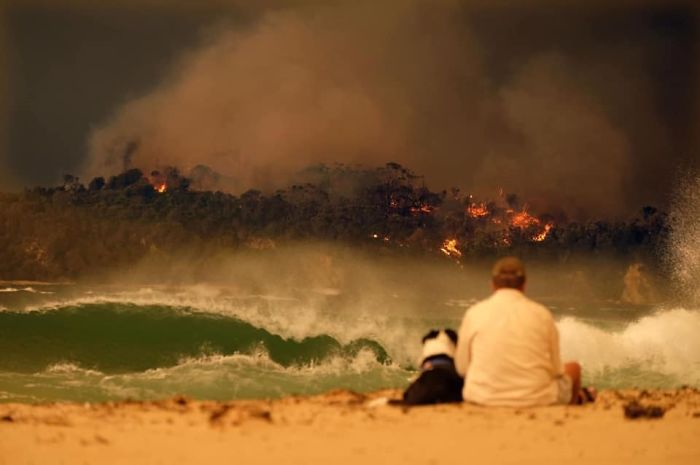

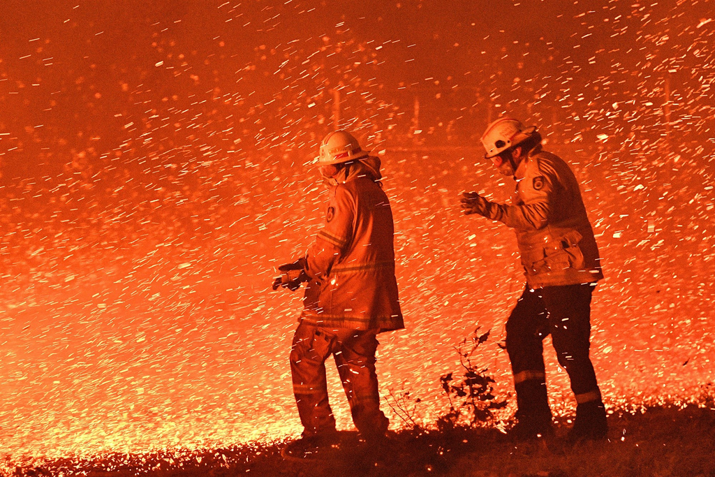

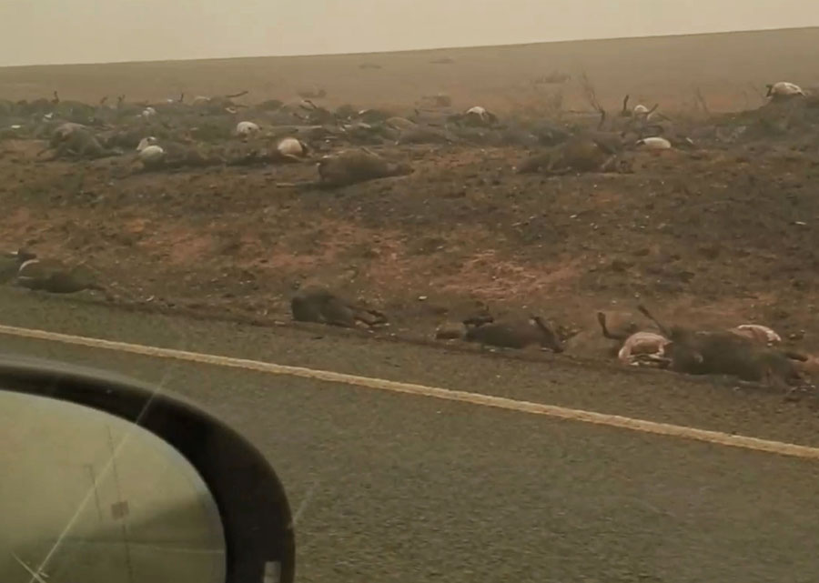

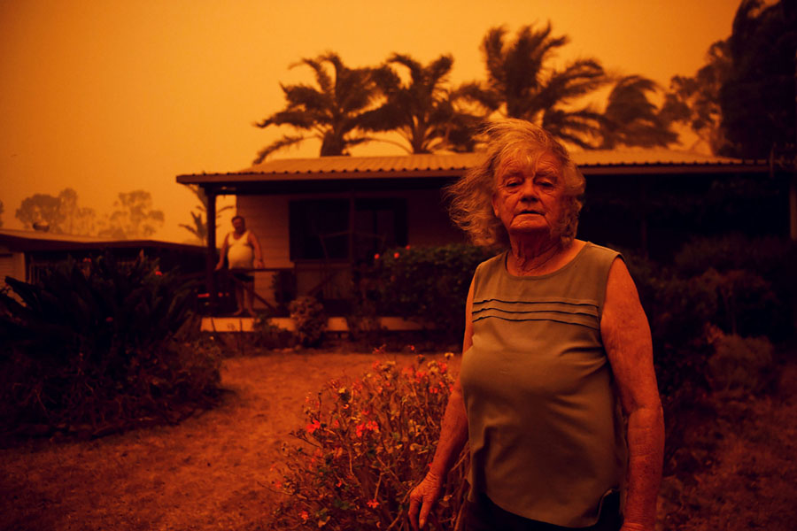

Please consider donating to the [Australian Red Cross](https://www.redcross.org.au/news-and-media/news/your-donations-in-action) to help support the firefighters, volunteers, and climate refugees.

This week’s dataset, from the [Australian Bureau of Meterology (BoM)](http://www.bom.gov.au/?ref=logo), will focus on this catastrophe. The data includes the maximum and minimum temperatures recorded at various locations in Australia from 1910 to 2019. Using inspiration from this [NYT article](https://www.nytimes.com/interactive/2020/01/02/climate/australia-fires-map.html), I will aim to visualize why this season’s fires have been so bad.

# R Program

## Set up

```r
# source utilities
source("../utilities.R")

# packages
library(tidyverse)
library(readr)

# set data path
data_path <- set_data_path()

# create plot folder if doesn't exist
if (!dir.exists("./plot")) {dir.create("./plot")}
```

## Load Data

```r
# read in data
temperature <- read_csv(paste0(data_path, "temperature.csv"), col_types=cols(date = col_date(format="%Y-%m-%d")))
```

## Manipulate Data

First, I found the average temperature recorded on each day across the different locations in Australia. I then took those measurements and grouped by year to find the average annual temperature.

```r
# find average temperature for each day
max_temp_date <- temperature %>%
    filter(temp_type == "max") %>%
    group_by(date) %>%
    summarise(daily_temp = mean(temperature, na.rm=TRUE))

# find average temperature for each year
max_temp_annual <- max_temp_date %>%
    mutate(year=format(date, "%Y")) %>%
    group_by(year) %>%
    summarise(annual_temp = mean(daily_temp, na.rm=TRUE))

# find difference of each year from average
max_temp_annual$annual_temp_diff <- max_temp_annual$annual_temp - mean(max_temp_annual[which(max_temp_annual$year %in% c(1960, 1961)),]$annual_temp)
```

## Plot

Using annotations, I was able to highlight and draw attention to the year 2019.

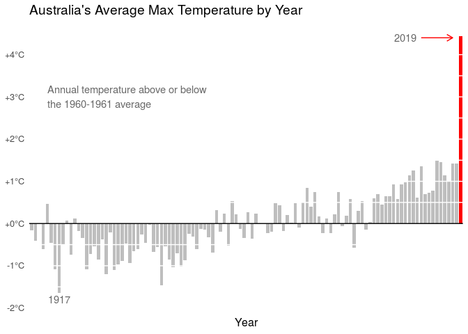

```r
# plot
p <- ggplot(data=max_temp_annual, aes(x=year, y=annual_temp_diff, fill=factor(ifelse(year==2019,"Highlighted","Normal")))) +

    # bar graph
    geom_bar(stat="identity", width=0.8) +

    # axes and colors
    scale_fill_manual(name="date", values=c("red","grey"))+
    theme(text = element_text(size=12), panel.background = element_blank(), panel.grid.major = element_blank(), axis.title.y=element_blank(), axis.text.x=element_blank(), axis.ticks.x=element_blank(), axis.ticks.y=element_blank(), legend.position="none") +
    xlab("Year") +
    scale_y_continuous(breaks=seq(floor(min(max_temp_annual$annual_temp_diff)), ceiling(max(max_temp_annual$annual_temp_diff)), by=1), labels=function(x) {ifelse(x>=0, paste0("+", x, "°C"), paste0(x, "°C"))}) +
    ggtitle("Australia's Average Max Temperature by Year") +

    # annotation arrow
    annotate("segment", x=100, xend=108, y=4.4, yend=4.4, colour="red", size=0.5, alpha=1, arrow=arrow(length=unit(0.1, "inches"))) +

    # annotation text
    annotate("text", x=5, y=3, hjust=0, label="Annual temperature above or below\nthe 1960-1961 average", color="dimgrey") +
    annotate("text", x=96, y=4.4, label="2019", color="dimgrey") +
    annotate("text", x=8, y=-1.8, label="1917", color="dimgrey") +

    # horizontal lines
    geom_hline(yintercept=c(-1.5, -1, -0.5, 0.5, 1, 1.5, 2, 2.5, 3, 3.5, 4), color="white", size=0.5) +
    geom_hline(yintercept=0, color="black", size=0.5)

p
```

It’s clear that 2019 has been the hottest year on record. No wonder the fires have been so bad.

One thing that I did notice is that the axes on graphic in the NYT article is not as drastic as mine. If anybody knows how our methodologies differed, please let me know!

## Save Image

```r
# save image
ggsave("plot/plot_2020-01-07.png", width=29, height=21, units="cm", dpi="retina")
```